# ANCOVA test for textual (engajamento no textual)

Geiser C. Challco geiser@alumni.usp.br

- Descriptive Statistics of Initial Data
- Checking of Assumptions
  - Assumption: Normality distribution of data
  - Assumption: Homogeneity of data distribution
- Computation of ANCOVA test and Pairwise Comparison
  - ANCOVA tests for one factor
  - ANCOVA tests for two factors
  - ANCOVA tests for grupo=“stari+WG”
  - Pairwise comparisons for one factor
    - factor: **grupo**
    - factor: **genero**
    - factor: **idade**
    - factor: **zona.participante**
    - factor: **escola**
    - factor: **zona.escola**
  - Pairwise comparisons for two factors
    - factores: **grupo:genero**
    - factores: **grupo:idade**
    - factores: **grupo:zona.participante**
    - factores: **grupo:escola**
    - factores: **grupo:zona.escola**
  - Pairwise comparisons for grupo=“Experimental”
    - factores: **grupo=“Experimental”:monitor**
    - factores: **grupo=“Experimental”:monitor.genero**
    - factores: **grupo=“Experimental”:monitor.area**
    - factores: **grupo=“Experimental”:monitor.formacao**
    - factores: **grupo=“Experimental”:monitor.experiencia**

**NOTE**

- Teste ANCOVA para determinar se houve diferenças significativas em referência ao engajamento no textual (medido como estado de fluxo).
- ANCOVA test to determine whether there were significant differences in reference to engagement in textual (measured as flow state).

# Descriptive Statistics of Initial Data

| grupo | genero | idade | zona.participante | escola | zona.escola | variable | n | mean | median | min | max | sd | se | ci | iqr |
| --- | --- | --- | --- | --- | --- | --- | --- | --- | --- | --- | --- | --- | --- | --- | --- |
| Controle | F |  |  |  |  | fss.textual | 6 | 3.426 | 3.222 | 2.889 | 4.444 | 0.542 | 0.221 | 0.568 | 0.250 |
| Controle | M |  |  |  |  | fss.textual | 8 | 3.085 | 2.889 | 2.556 | 4.125 | 0.554 | 0.196 | 0.463 | 0.667 |
| stari+WG | F |  |  |  |  | fss.textual | 4 | 3.250 | 3.000 | 2.667 | 4.333 | 0.739 | 0.370 | 1.176 | 0.417 |
| stari+WG | M |  |  |  |  | fss.textual | 12 | 3.454 | 3.444 | 2.889 | 4.222 | 0.433 | 0.125 | 0.275 | 0.722 |
| Controle | F |  |  |  |  | dfs.textual | 6 | 2.963 | 3.000 | 2.556 | 3.444 | 0.295 | 0.121 | 0.310 | 0.167 |
| Controle | M |  |  |  |  | dfs.textual | 8 | 2.981 | 3.111 | 2.000 | 3.667 | 0.526 | 0.186 | 0.440 | 0.677 |
| stari+WG | F |  |  |  |  | dfs.textual | 4 | 2.802 | 2.714 | 2.222 | 3.556 | 0.601 | 0.300 | 0.956 | 0.762 |
| stari+WG | M |  |  |  |  | dfs.textual | 12 | 3.278 | 3.056 | 2.778 | 4.222 | 0.448 | 0.129 | 0.285 | 0.611 |
| Controle |  | 10y |  |  |  | fss.textual | 4 | 3.528 | 3.389 | 2.889 | 4.444 | 0.669 | 0.334 | 1.064 | 0.639 |
| Controle |  | 11y |  |  |  | fss.textual | 6 | 3.188 | 3.056 | 2.556 | 4.125 | 0.611 | 0.250 | 0.642 | 0.833 |
| Controle |  | 12y |  |  |  | fss.textual | 2 | 2.944 | 2.944 | 2.667 | 3.222 | 0.393 | 0.278 | 3.530 | 0.278 |
| Controle |  | 13y |  |  |  | fss.textual | 1 | 3.222 | 3.222 | 3.222 | 3.222 |  |  |  | 0.000 |
| Controle |  | 15y |  |  |  | fss.textual | 1 | 2.889 | 2.889 | 2.889 | 2.889 |  |  |  | 0.000 |
| stari+WG |  | 10y |  |  |  | fss.textual | 2 | 4.000 | 4.000 | 3.778 | 4.222 | 0.314 | 0.222 | 2.824 | 0.222 |
| stari+WG |  | 11y |  |  |  | fss.textual | 9 | 3.272 | 3.333 | 2.667 | 3.889 | 0.365 | 0.122 | 0.280 | 0.444 |
| stari+WG |  | 12y |  |  |  | fss.textual | 2 | 4.111 | 4.111 | 3.889 | 4.333 | 0.314 | 0.222 | 2.824 | 0.222 |
| stari+WG |  | 13y |  |  |  | fss.textual | 3 | 2.926 | 2.889 | 2.889 | 3.000 | 0.064 | 0.037 | 0.159 | 0.056 |
| Controle |  | 10y |  |  |  | dfs.textual | 4 | 3.056 | 3.000 | 2.778 | 3.444 | 0.280 | 0.140 | 0.445 | 0.167 |
| Controle |  | 11y |  |  |  | dfs.textual | 6 | 3.178 | 3.222 | 2.625 | 3.667 | 0.355 | 0.145 | 0.372 | 0.306 |
| Controle |  | 12y |  |  |  | dfs.textual | 2 | 2.889 | 2.889 | 2.667 | 3.111 | 0.314 | 0.222 | 2.824 | 0.222 |
| Controle |  | 13y |  |  |  | dfs.textual | 1 | 2.556 | 2.556 | 2.556 | 2.556 |  |  |  | 0.000 |
| Controle |  | 15y |  |  |  | dfs.textual | 1 | 2.000 | 2.000 | 2.000 | 2.000 |  |  |  | 0.000 |
| stari+WG |  | 10y |  |  |  | dfs.textual | 2 | 2.944 | 2.944 | 2.889 | 3.000 | 0.079 | 0.056 | 0.706 | 0.056 |
| stari+WG |  | 11y |  |  |  | dfs.textual | 9 | 3.171 | 3.000 | 2.222 | 4.222 | 0.641 | 0.214 | 0.493 | 0.667 |
| stari+WG |  | 12y |  |  |  | dfs.textual | 2 | 3.333 | 3.333 | 3.111 | 3.556 | 0.314 | 0.222 | 2.824 | 0.222 |
| stari+WG |  | 13y |  |  |  | dfs.textual | 3 | 3.148 | 3.000 | 2.778 | 3.667 | 0.463 | 0.267 | 1.149 | 0.444 |
| Controle |  |  | Urbana |  |  | fss.textual | 9 | 3.273 | 3.222 | 2.556 | 4.444 | 0.619 | 0.206 | 0.476 | 0.333 |
| Controle |  |  | Rural |  |  | fss.textual | 2 | 2.944 | 2.944 | 2.667 | 3.222 | 0.393 | 0.278 | 3.530 | 0.278 |
| Controle |  |  |  |  |  | fss.textual | 3 | 3.296 | 3.556 | 2.667 | 3.667 | 0.548 | 0.316 | 1.362 | 0.500 |
| stari+WG |  |  | Urbana |  |  | fss.textual | 6 | 3.463 | 3.444 | 2.667 | 4.333 | 0.598 | 0.244 | 0.628 | 0.667 |
| stari+WG |  |  | Rural |  |  | fss.textual | 5 | 3.444 | 3.333 | 3.000 | 4.222 | 0.484 | 0.217 | 0.601 | 0.444 |
| stari+WG |  |  |  |  |  | fss.textual | 5 | 3.289 | 3.000 | 2.889 | 3.889 | 0.501 | 0.224 | 0.622 | 0.889 |
| Controle |  |  | Urbana |  |  | dfs.textual | 9 | 3.049 | 3.111 | 2.000 | 3.667 | 0.475 | 0.158 | 0.365 | 0.333 |
| Controle |  |  | Rural |  |  | dfs.textual | 2 | 2.590 | 2.590 | 2.556 | 2.625 | 0.049 | 0.035 | 0.441 | 0.035 |
| Controle |  |  |  |  |  | dfs.textual | 3 | 3.000 | 3.000 | 2.667 | 3.333 | 0.333 | 0.192 | 0.828 | 0.333 |
| stari+WG |  |  | Urbana |  |  | dfs.textual | 6 | 3.463 | 3.500 | 2.889 | 4.222 | 0.484 | 0.198 | 0.508 | 0.528 |
| stari+WG |  |  | Rural |  |  | dfs.textual | 5 | 3.152 | 3.000 | 2.429 | 3.778 | 0.530 | 0.237 | 0.658 | 0.556 |
| stari+WG |  |  |  |  |  | dfs.textual | 5 | 2.800 | 2.889 | 2.222 | 3.111 | 0.346 | 0.155 | 0.430 | 0.222 |
| Controle |  |  |  | E1 |  | fss.textual | 5 | 3.267 | 2.889 | 2.889 | 4.444 | 0.674 | 0.301 | 0.837 | 0.333 |
| Controle |  |  |  | E2 |  | fss.textual | 1 | 2.667 | 2.667 | 2.667 | 2.667 |  |  |  | 0.000 |
| Controle |  |  |  | E4 |  | fss.textual | 1 | 3.222 | 3.222 | 3.222 | 3.222 |  |  |  | 0.000 |
| Controle |  |  |  | E5 |  | fss.textual | 5 | 3.158 | 3.222 | 2.556 | 4.125 | 0.622 | 0.278 | 0.772 | 0.556 |
| Controle |  |  |  | E6 |  | fss.textual | 2 | 3.611 | 3.611 | 3.556 | 3.667 | 0.079 | 0.056 | 0.706 | 0.056 |
| stari+WG |  |  |  | E2 |  | fss.textual | 2 | 3.111 | 3.111 | 2.889 | 3.333 | 0.314 | 0.222 | 2.824 | 0.222 |
| stari+WG |  |  |  | E4 |  | fss.textual | 5 | 3.444 | 3.444 | 3.000 | 4.222 | 0.478 | 0.214 | 0.593 | 0.333 |
| stari+WG |  |  |  | E5 |  | fss.textual | 7 | 3.333 | 3.000 | 2.667 | 4.333 | 0.609 | 0.230 | 0.563 | 0.778 |
| stari+WG |  |  |  | E6 |  | fss.textual | 2 | 3.833 | 3.833 | 3.778 | 3.889 | 0.079 | 0.056 | 0.706 | 0.056 |
| Controle |  |  |  | E1 |  | dfs.textual | 5 | 2.911 | 3.000 | 2.000 | 3.444 | 0.574 | 0.257 | 0.713 | 0.556 |
| Controle |  |  |  | E2 |  | dfs.textual | 1 | 2.667 | 2.667 | 2.667 | 2.667 |  |  |  | 0.000 |
| Controle |  |  |  | E4 |  | dfs.textual | 1 | 3.111 | 3.111 | 3.111 | 3.111 |  |  |  | 0.000 |
| Controle |  |  |  | E5 |  | dfs.textual | 5 | 2.992 | 3.000 | 2.556 | 3.667 | 0.446 | 0.199 | 0.553 | 0.486 |
| Controle |  |  |  | E6 |  | dfs.textual | 2 | 3.167 | 3.167 | 3.000 | 3.333 | 0.236 | 0.167 | 2.118 | 0.167 |
| stari+WG |  |  |  | E2 |  | dfs.textual | 2 | 3.278 | 3.278 | 3.000 | 3.556 | 0.393 | 0.278 | 3.530 | 0.278 |
| stari+WG |  |  |  | E4 |  | dfs.textual | 5 | 3.511 | 3.667 | 2.889 | 4.222 | 0.559 | 0.250 | 0.694 | 0.778 |
| stari+WG |  |  |  | E5 |  | dfs.textual | 7 | 2.918 | 3.000 | 2.222 | 3.556 | 0.490 | 0.185 | 0.453 | 0.619 |
| stari+WG |  |  |  | E6 |  | dfs.textual | 2 | 3.000 | 3.000 | 2.889 | 3.111 | 0.157 | 0.111 | 1.412 | 0.111 |
| Controle |  |  |  |  | Urbana | fss.textual | 11 | 3.163 | 2.889 | 2.556 | 4.444 | 0.605 | 0.183 | 0.407 | 0.444 |
| Controle |  |  |  |  | Rural | fss.textual | 3 | 3.481 | 3.556 | 3.222 | 3.667 | 0.231 | 0.134 | 0.575 | 0.222 |
| stari+WG |  |  |  |  | Urbana | fss.textual | 9 | 3.284 | 3.000 | 2.667 | 4.333 | 0.547 | 0.182 | 0.421 | 0.667 |
| stari+WG |  |  |  |  | Rural | fss.textual | 7 | 3.556 | 3.444 | 3.000 | 4.222 | 0.435 | 0.164 | 0.402 | 0.556 |
| Controle |  |  |  |  | Urbana | dfs.textual | 11 | 2.926 | 3.000 | 2.000 | 3.667 | 0.469 | 0.142 | 0.315 | 0.576 |
| Controle |  |  |  |  | Rural | dfs.textual | 3 | 3.148 | 3.111 | 3.000 | 3.333 | 0.170 | 0.098 | 0.422 | 0.167 |
| stari+WG |  |  |  |  | Urbana | dfs.textual | 9 | 2.998 | 3.000 | 2.222 | 3.556 | 0.474 | 0.158 | 0.364 | 0.667 |
| stari+WG |  |  |  |  | Rural | dfs.textual | 7 | 3.365 | 3.111 | 2.889 | 4.222 | 0.524 | 0.198 | 0.485 | 0.778 |

# Checking of Assumptions

## Assumption: Normality distribution of data

| var | n | skewness | kurtosis | symmetry | statistic | method | p | p.signif | normality |
| --- | --- | --- | --- | --- | --- | --- | --- | --- | --- |
| fss.textual | 30 | 0.5520271 | -0.8000782 | NO | 0.9371436 | Shapiro-Wilk | 0.0762094 | ns | YES |
| fss.textual | 30 | 0.3939191 | 0.2752054 | YES | 0.9729100 | Shapiro-Wilk | 0.6214655 | ns | YES |
| fss.textual | 22 | 0.5801373 | -0.7138465 | NO | 0.9362644 | Shapiro-Wilk | 0.1656476 | ns | YES |
| fss.textual | 30 | 0.6353309 | -0.0650922 | NO | 0.9264994 | Shapiro-Wilk | 0.0396712 | * | NO |
| fss.textual | 30 | 0.6458306 | -0.3832718 | NO | 0.9499883 | Shapiro-Wilk | 0.1689379 | ns | YES |

## Assumption: Homogeneity of data distribution

| var | method | formula | n | DFn.df1 | DFd.df2 | statistic | p | p.signif |
| --- | --- | --- | --- | --- | --- | --- | --- | --- |
| fss.textual | Levene’s test | `.res`~`grupo`*`genero` | 30 | 3 | 26 | 0.1763847 | 0.9114188 | ns |
| fss.textual | Anova’s slopes | `.res`~`grupo`*`genero` | 30 | 3 | 22 | 1.6790000 | 0.2000000 | ns |
| fss.textual | Levene’s test | `.res`~`grupo`*`idade` | 30 | 8 | 21 | 1.3741087 | 0.2639380 | ns |
| fss.textual | Anova’s slopes | `.res`~`grupo`*`idade` | 30 | 6 | 14 | 0.7800000 | 0.5990000 | ns |
| fss.textual | Levene’s test | `.res`~`grupo`*`zona.participante` | 22 | 3 | 18 | 0.1520575 | 0.9270076 | ns |
| fss.textual | Anova’s slopes | `.res`~`grupo`*`zona.participante` | 22 | 3 | 14 | 0.2020000 | 0.8930000 | ns |
| fss.textual | Levene’s test | `.res`~`grupo`*`escola` | 30 | 8 | 21 | 0.7872244 | 0.6192315 | ns |
| fss.textual | Anova’s slopes | `.res`~`grupo`*`escola` | 30 | 6 | 14 | 0.8360000 | 0.5620000 | ns |
| fss.textual | Levene’s test | `.res`~`grupo`*`zona.escola` | 30 | 3 | 26 | 0.6981231 | 0.5616503 | ns |
| fss.textual | Anova’s slopes | `.res`~`grupo`*`zona.escola` | 30 | 3 | 22 | 1.8490000 | 0.1680000 | ns |

# Computation of ANCOVA test and Pairwise Comparison

## ANCOVA tests for one factor

|  | Effect | DFn | DFd | SSn | SSd | F | p | ges | p<.05 |
| --- | --- | --- | --- | --- | --- | --- | --- | --- | --- |
| 1 | dfs.textual | 1 | 27 | 0.558 | 7.278 | 2.068 | 0.162 | 0.071 |  |
| 2 | grupo | 1 | 27 | 0.098 | 7.278 | 0.362 | 0.552 | 0.013 |  |
| 4 | genero | 1 | 27 | 0.126 | 7.249 | 0.471 | 0.498 | 0.017 |  |
| 6 | idade | 4 | 24 | 1.589 | 5.787 | 1.647 | 0.195 | 0.215 |  |
| 8 | zona.participante | 1 | 19 | 0.000 | 6.083 | 0.002 | 0.969 | 0.000 |  |
| 10 | escola | 4 | 24 | 1.030 | 6.345 | 0.974 | 0.440 | 0.140 |  |
| 12 | zona.escola | 1 | 27 | 0.322 | 7.054 | 1.232 | 0.277 | 0.044 |  |

## ANCOVA tests for two factors

|  | Effect | DFn | DFd | SSn | SSd | F | p | ges | p<.05 |
| --- | --- | --- | --- | --- | --- | --- | --- | --- | --- |
| 1 | dfs.textual | 1 | 25 | 0.458 | 6.855 | 1.671 | 0.208 | 0.063 |  |
| 4 | grupo:genero | 1 | 25 | 0.259 | 6.855 | 0.946 | 0.340 | 0.036 |  |
| 8 | grupo:idade | 3 | 20 | 1.190 | 4.190 | 1.894 | 0.163 | 0.221 |  |
| 12 | grupo:zona.participante | 1 | 17 | 0.083 | 5.839 | 0.243 | 0.628 | 0.014 |  |
| 16 | grupo:escola | 3 | 20 | 0.016 | 6.106 | 0.018 | 0.997 | 0.003 |  |
| 20 | grupo:zona.escola | 1 | 25 | 0.009 | 6.999 | 0.034 | 0.855 | 0.001 |  |

## ANCOVA tests for grupo=“stari+WG”

|  | Effect | DFn | DFd | SSn | SSd | F | p | ges | p<.05 |
| --- | --- | --- | --- | --- | --- | --- | --- | --- | --- |
| 1 | dfs.textual | 1 | 4 | 0.232 | 0.688 | 1.346 | 0.310 | 0.252 |  |
| 2 | monitor | 5 | 4 | 1.334 | 0.688 | 1.551 | 0.346 | 0.660 |  |
| 4 | monitor.genero | 1 | 8 | 0.049 | 1.974 | 0.198 | 0.668 | 0.024 |  |
| 6 | monitor.area | 5 | 4 | 1.334 | 0.688 | 1.551 | 0.346 | 0.660 |  |
| 8 | monitor.formacao | 2 | 7 | 0.084 | 1.938 | 0.152 | 0.862 | 0.042 |  |
| 10 | monitor.experiencia | 1 | 8 | 0.000 | 2.022 | 0.002 | 0.967 | 0.000 |  |

## Pairwise comparisons for one factor

### factor: **grupo**

| var | grupo | n | M (pre) | SE (pre) | M (unadj) | SE (unadj) | M (adj) | SE (adj) |
| --- | --- | --- | --- | --- | --- | --- | --- | --- |
| fss.textual | Controle | 14 | 2.973 | 0.114 | 3.231 | 0.148 | 3.260 | 0.140 |
| fss.textual | stari+WG | 16 | 3.159 | 0.129 | 3.403 | 0.126 | 3.377 | 0.131 |

| .y. | group1 | group2 | estimate | conf.low | conf.high | se | statistic | p | p.adj | p.adj.signif |
| --- | --- | --- | --- | --- | --- | --- | --- | --- | --- | --- |
| fss.textual | Controle | stari+WG | -0.117 | -0.514 | 0.281 | 0.194 | -0.602 | 0.552 | 0.552 | ns |
| dfs.textual | Controle | stari+WG | -0.186 | -0.543 | 0.171 | 0.174 | -1.064 | 0.296 | 0.296 | ns |

| .y. | grupo | group1 | group2 | estimate | conf.low | conf.high | se | statistic | p | p.adj | p.adj.signif |
| --- | --- | --- | --- | --- | --- | --- | --- | --- | --- | --- | --- |
| flow.textual | Controle | pre | pos | -0.258 | -0.639 | 0.123 | 0.190 | -1.356 | 0.181 | 0.181 | ns |
| flow.textual | stari+WG | pre | pos | -0.244 | -0.601 | 0.112 | 0.178 | -1.371 | 0.176 | 0.176 | ns |

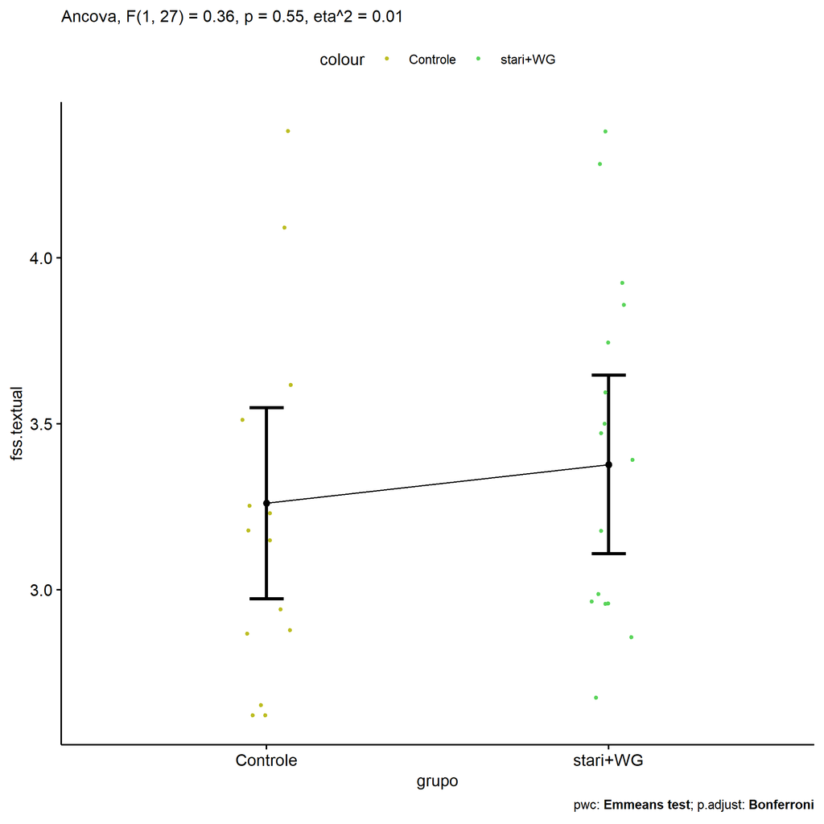

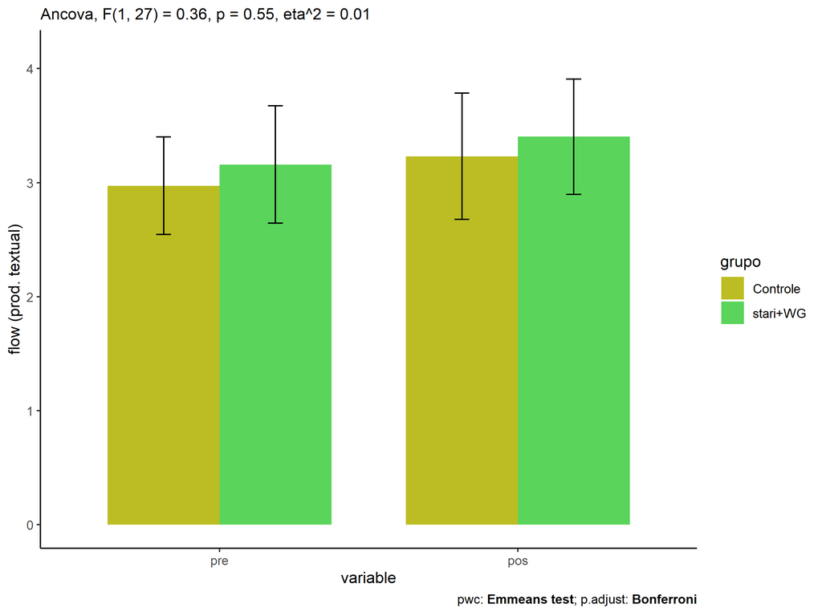

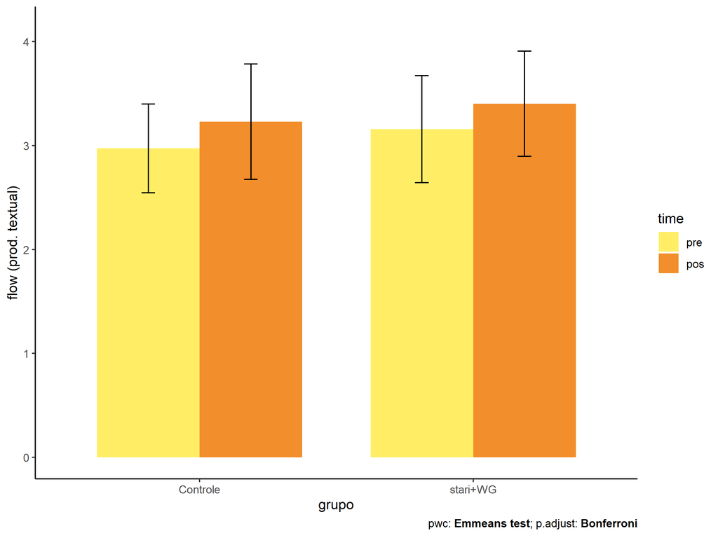

### factor: **genero**

| var | genero | n | M (pre) | SE (pre) | M (unadj) | SE (unadj) | M (adj) | SE (adj) |
| --- | --- | --- | --- | --- | --- | --- | --- | --- |
| fss.textual | F | 10 | 2.898 | 0.133 | 3.356 | 0.188 | 3.418 | 0.168 |
| fss.textual | M | 20 | 3.159 | 0.110 | 3.306 | 0.113 | 3.275 | 0.117 |

| .y. | group1 | group2 | estimate | conf.low | conf.high | se | statistic | p | p.adj | p.adj.signif |
| --- | --- | --- | --- | --- | --- | --- | --- | --- | --- | --- |
| fss.textual | F | M | 0.143 | -0.284 | 0.569 | 0.208 | 0.686 | 0.498 | 0.498 | ns |
| dfs.textual | F | M | -0.261 | -0.633 | 0.111 | 0.182 | -1.435 | 0.162 | 0.162 | ns |

| .y. | genero | group1 | group2 | estimate | conf.low | conf.high | se | statistic | p | p.adj | p.adj.signif |
| --- | --- | --- | --- | --- | --- | --- | --- | --- | --- | --- | --- |
| flow.textual | F | pre | pos | -0.457 | -0.908 | -0.006 | 0.225 | -2.030 | 0.047 | 0.047 | * |
| flow.textual | M | pre | pos | -0.147 | -0.466 | 0.172 | 0.159 | -0.925 | 0.359 | 0.359 | ns |

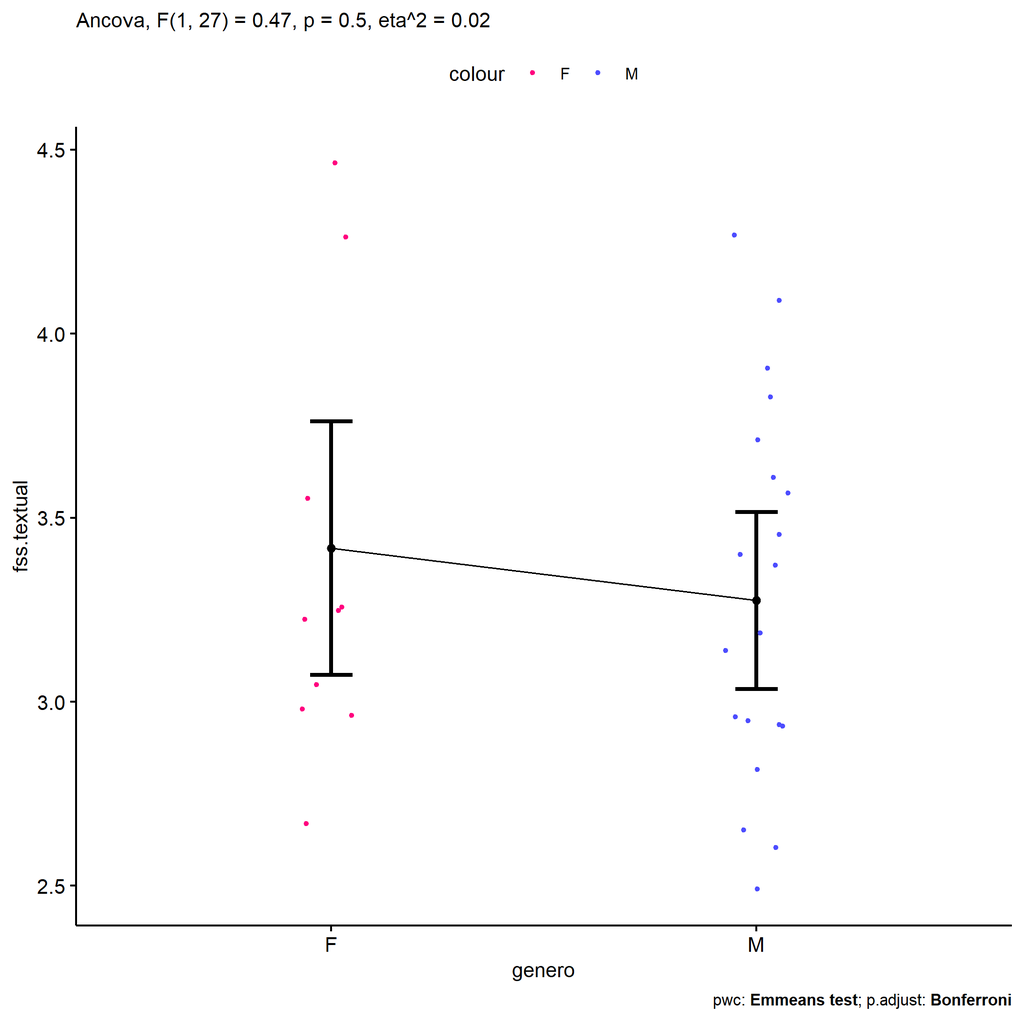

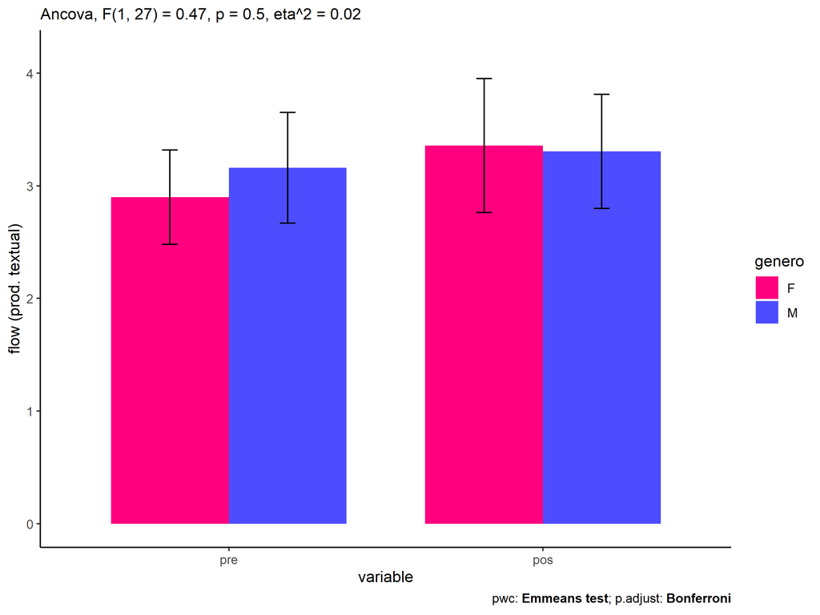

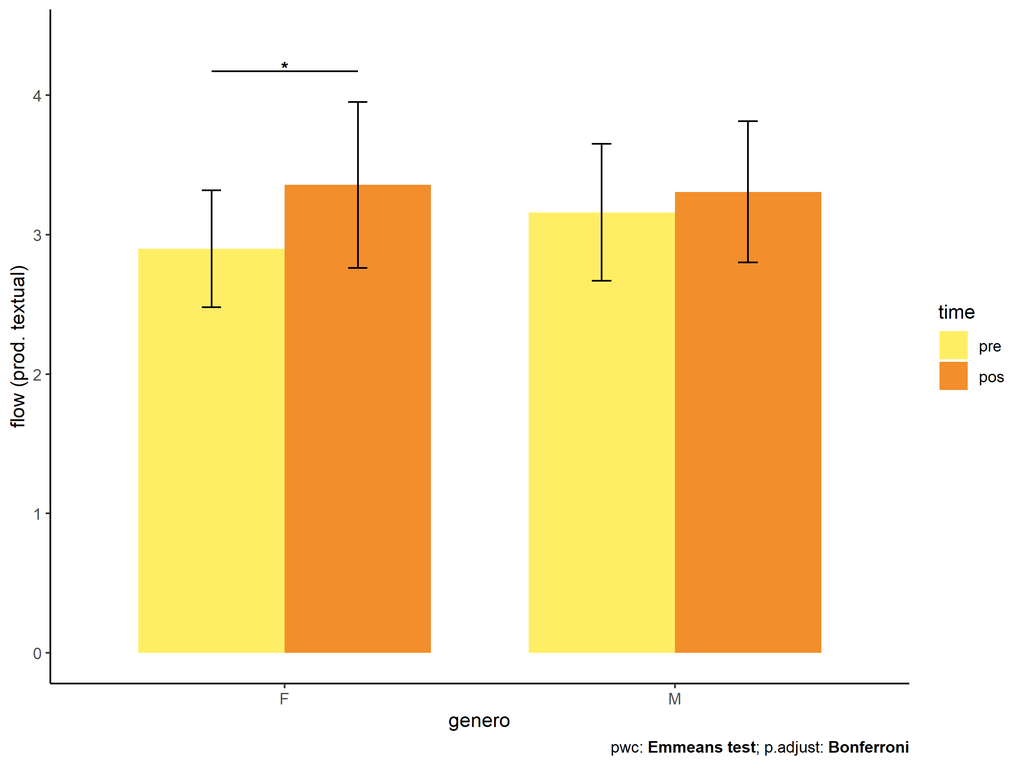

### factor: **idade**

| var | idade | n | M (pre) | SE (pre) | M (unadj) | SE (unadj) | M (adj) | SE (adj) |
| --- | --- | --- | --- | --- | --- | --- | --- | --- |
| fss.textual | 10y | 6 | 3.019 | 0.093 | 3.685 | 0.241 | 3.715 | 0.204 |
| fss.textual | 11y | 15 | 3.174 | 0.137 | 3.238 | 0.119 | 3.226 | 0.128 |

| .y. | group1 | group2 | estimate | conf.low | conf.high | se | statistic | p | p.adj | p.adj.signif |
| --- | --- | --- | --- | --- | --- | --- | --- | --- | --- | --- |
| fss.textual | 10y | 11y | 0.489 | -0.020 | 0.997 | 0.242 | 2.020 | 0.059 | 0.059 | ns |
| dfs.textual | 10y | 11y | -0.155 | -0.629 | 0.318 | 0.226 | -0.687 | 0.501 | 0.501 | ns |

| .y. | idade | group1 | group2 | estimate | conf.low | conf.high | se | statistic | p | p.adj | p.adj.signif |
| --- | --- | --- | --- | --- | --- | --- | --- | --- | --- | --- | --- |
| flow.textual | 10y | pre | pos | -0.667 | -1.231 | -0.102 | 0.279 | -2.390 | 0.022 | 0.022 | * |
| flow.textual | 11y | pre | pos | -0.064 | -0.421 | 0.293 | 0.176 | -0.363 | 0.719 | 0.719 | ns |

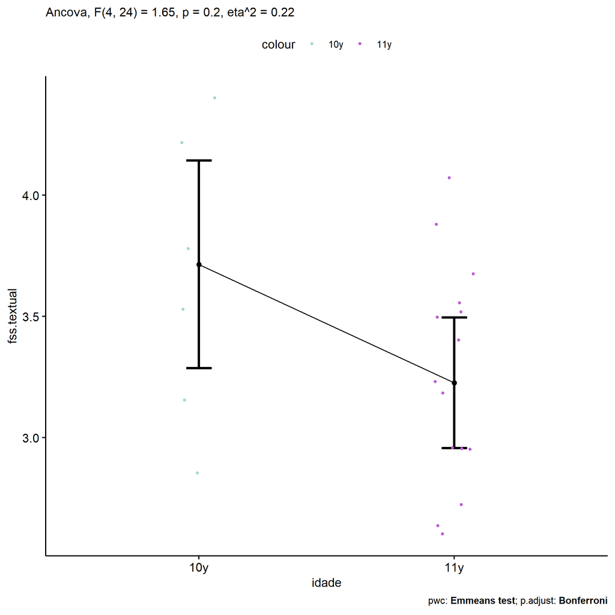

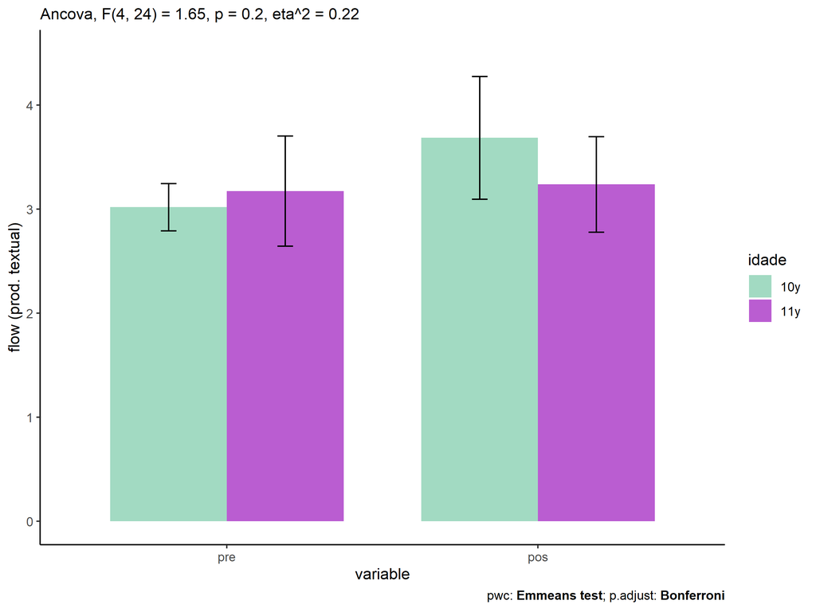

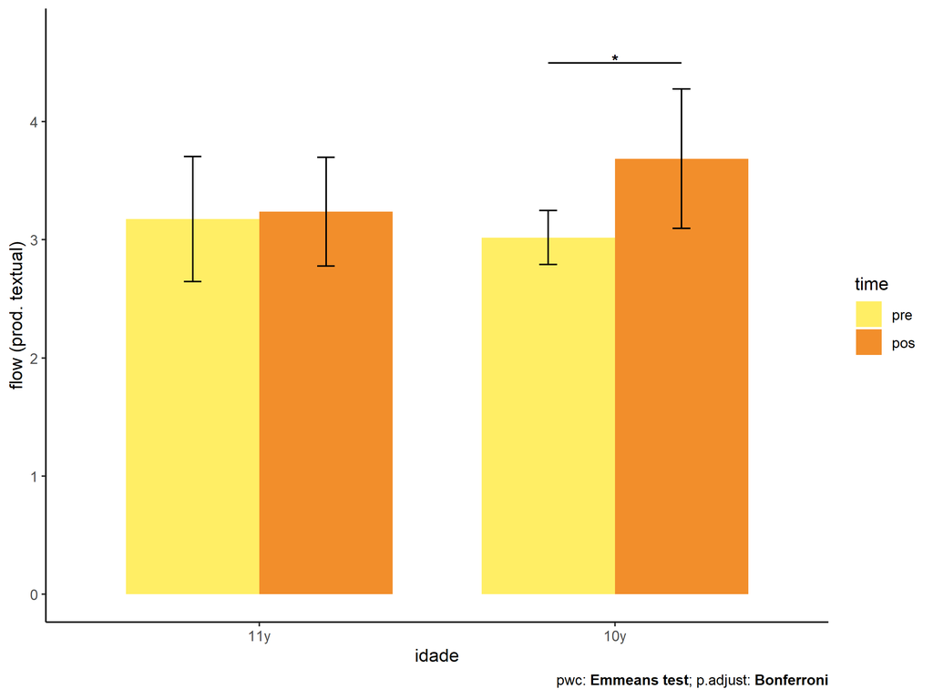

### factor: **zona.participante**

| var | zona.participante | n | M (pre) | SE (pre) | M (unadj) | SE (unadj) | M (adj) | SE (adj) |
| --- | --- | --- | --- | --- | --- | --- | --- | --- |
| fss.textual | Rural | 7 | 2.992 | 0.194 | 3.302 | 0.186 | 3.341 | 0.217 |
| fss.textual | Urbana | 15 | 3.215 | 0.131 | 3.349 | 0.154 | 3.331 | 0.147 |

| .y. | group1 | group2 | estimate | conf.low | conf.high | se | statistic | p | p.adj | p.adj.signif |
| --- | --- | --- | --- | --- | --- | --- | --- | --- | --- | --- |
| fss.textual | Urbana | Rural | -0.010 | -0.565 | 0.544 | 0.265 | -0.039 | 0.969 | 0.969 | ns |
| dfs.textual | Urbana | Rural | 0.223 | -0.262 | 0.708 | 0.233 | 0.958 | 0.349 | 0.349 | ns |

| .y. | zona.participante | group1 | group2 | estimate | conf.low | conf.high | se | statistic | p | p.adj | p.adj.signif |
| --- | --- | --- | --- | --- | --- | --- | --- | --- | --- | --- | --- |
| flow.textual | Urbana | pre | pos | -0.134 | -0.532 | 0.263 | 0.197 | -0.683 | 0.499 | 0.499 | ns |
| flow.textual | Rural | pre | pos | -0.310 | -0.892 | 0.272 | 0.288 | -1.076 | 0.288 | 0.288 | ns |

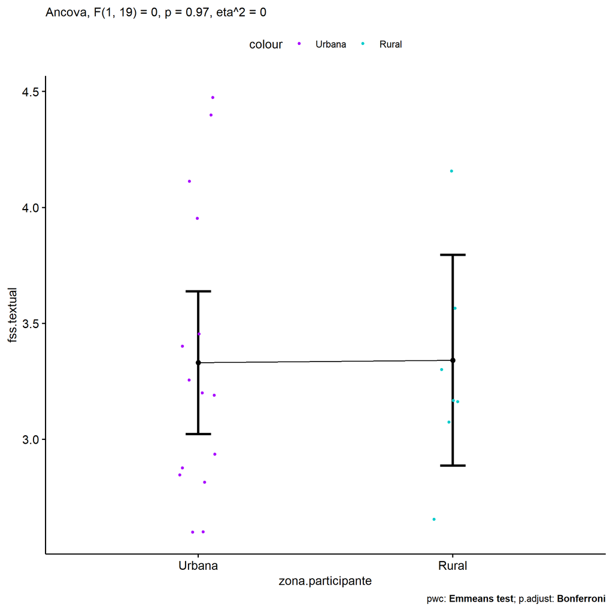

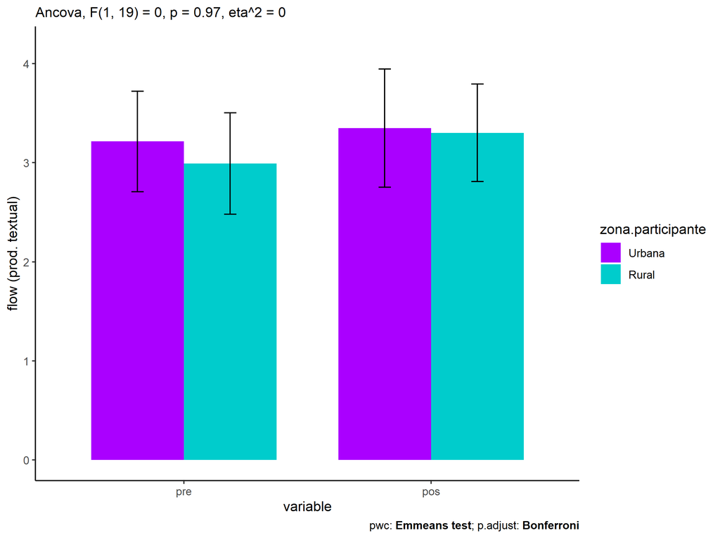

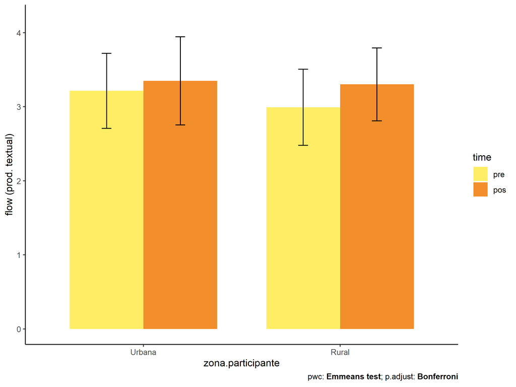

### factor: **escola**

| var | escola | n | M (pre) | SE (pre) | M (unadj) | SE (unadj) | M (adj) | SE (adj) |
| --- | --- | --- | --- | --- | --- | --- | --- | --- |
| fss.textual | E1 | 5 | 2.911 | 0.257 | 3.267 | 0.301 | 3.314 | 0.258 |
| fss.textual | E4 | 6 | 3.444 | 0.215 | 3.407 | 0.178 | 3.296 | 0.252 |
| fss.textual | E5 | 12 | 2.949 | 0.131 | 3.260 | 0.171 | 3.297 | 0.168 |

| .y. | group1 | group2 | estimate | conf.low | conf.high | se | statistic | p | p.adj | p.adj.signif |
| --- | --- | --- | --- | --- | --- | --- | --- | --- | --- | --- |
| fss.textual | E1 | E4 | 0.019 | -0.759 | 0.797 | 0.372 | 0.050 | 0.961 | 1.000 | ns |
| fss.textual | E1 | E5 | 0.018 | -0.619 | 0.654 | 0.304 | 0.058 | 0.955 | 1.000 | ns |
| fss.textual | E4 | E5 | -0.001 | -0.655 | 0.653 | 0.312 | -0.003 | 0.997 | 1.000 | ns |
| dfs.textual | E1 | E4 | -0.533 | -1.162 | 0.095 | 0.301 | -1.770 | 0.092 | 0.276 | ns |
| dfs.textual | E1 | E5 | -0.038 | -0.590 | 0.515 | 0.265 | -0.143 | 0.888 | 1.000 | ns |
| dfs.textual | E4 | E5 | 0.496 | -0.023 | 1.015 | 0.249 | 1.992 | 0.060 | 0.181 | ns |

| .y. | escola | group1 | group2 | estimate | conf.low | conf.high | se | statistic | p | p.adj | p.adj.signif |
| --- | --- | --- | --- | --- | --- | --- | --- | --- | --- | --- | --- |
| flow.textual | E1 | pre | pos | -0.356 | -1.043 | 0.332 | 0.340 | -1.045 | 0.302 | 0.302 | ns |
| flow.textual | E4 | pre | pos | 0.037 | -0.591 | 0.665 | 0.311 | 0.119 | 0.906 | 0.906 | ns |
| flow.textual | E5 | pre | pos | -0.312 | -0.756 | 0.132 | 0.220 | -1.418 | 0.164 | 0.164 | ns |

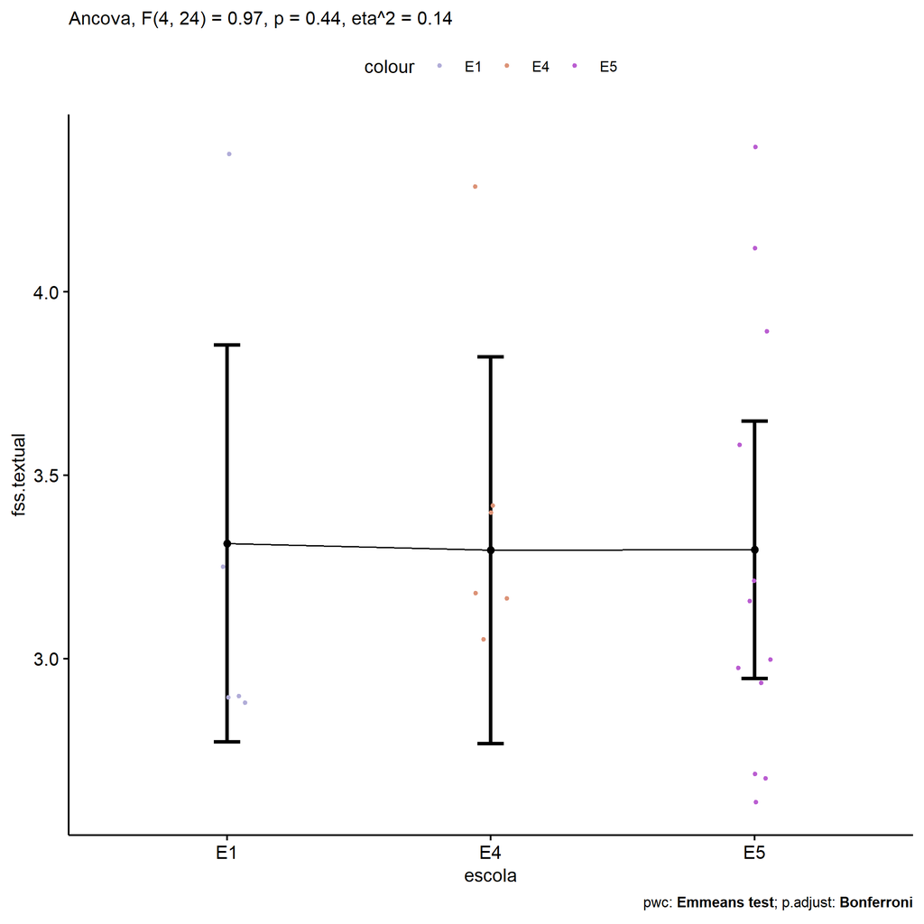

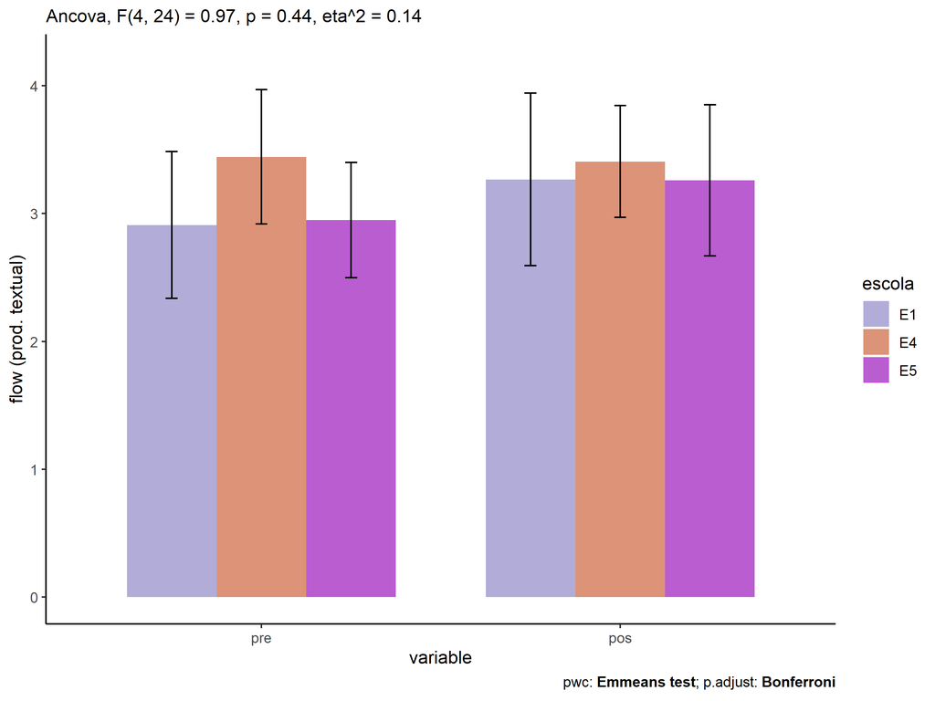

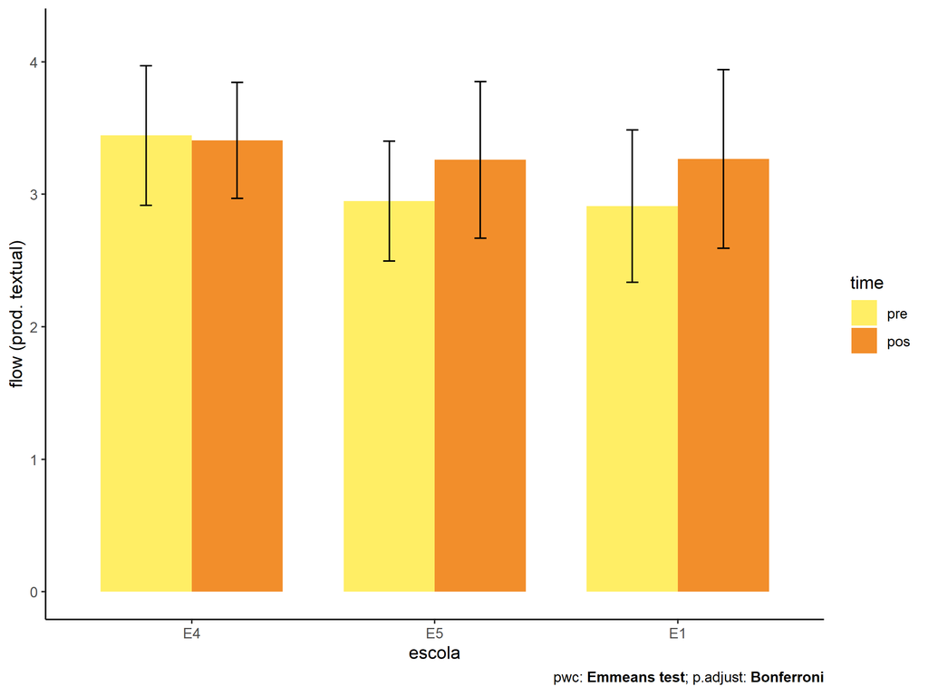

### factor: **zona.escola**

| var | zona.escola | n | M (pre) | SE (pre) | M (unadj) | SE (unadj) | M (adj) | SE (adj) |
| --- | --- | --- | --- | --- | --- | --- | --- | --- |
| fss.textual | Rural | 10 | 3.300 | 0.142 | 3.533 | 0.118 | 3.479 | 0.169 |
| fss.textual | Urbana | 20 | 2.958 | 0.103 | 3.217 | 0.127 | 3.245 | 0.117 |

| .y. | group1 | group2 | estimate | conf.low | conf.high | se | statistic | p | p.adj | p.adj.signif |
| --- | --- | --- | --- | --- | --- | --- | --- | --- | --- | --- |
| fss.textual | Urbana | Rural | -0.234 | -0.666 | 0.199 | 0.211 | -1.110 | 0.277 | 0.277 | ns |
| dfs.textual | Urbana | Rural | -0.342 | -0.704 | 0.020 | 0.177 | -1.934 | 0.063 | 0.063 | ns |

| .y. | zona.escola | group1 | group2 | estimate | conf.low | conf.high | se | statistic | p | p.adj | p.adj.signif |
| --- | --- | --- | --- | --- | --- | --- | --- | --- | --- | --- | --- |
| flow.textual | Urbana | pre | pos | -0.259 | -0.567 | 0.049 | 0.154 | -1.687 | 0.097 | 0.097 | ns |
| flow.textual | Rural | pre | pos | -0.233 | -0.669 | 0.202 | 0.217 | -1.074 | 0.287 | 0.287 | ns |

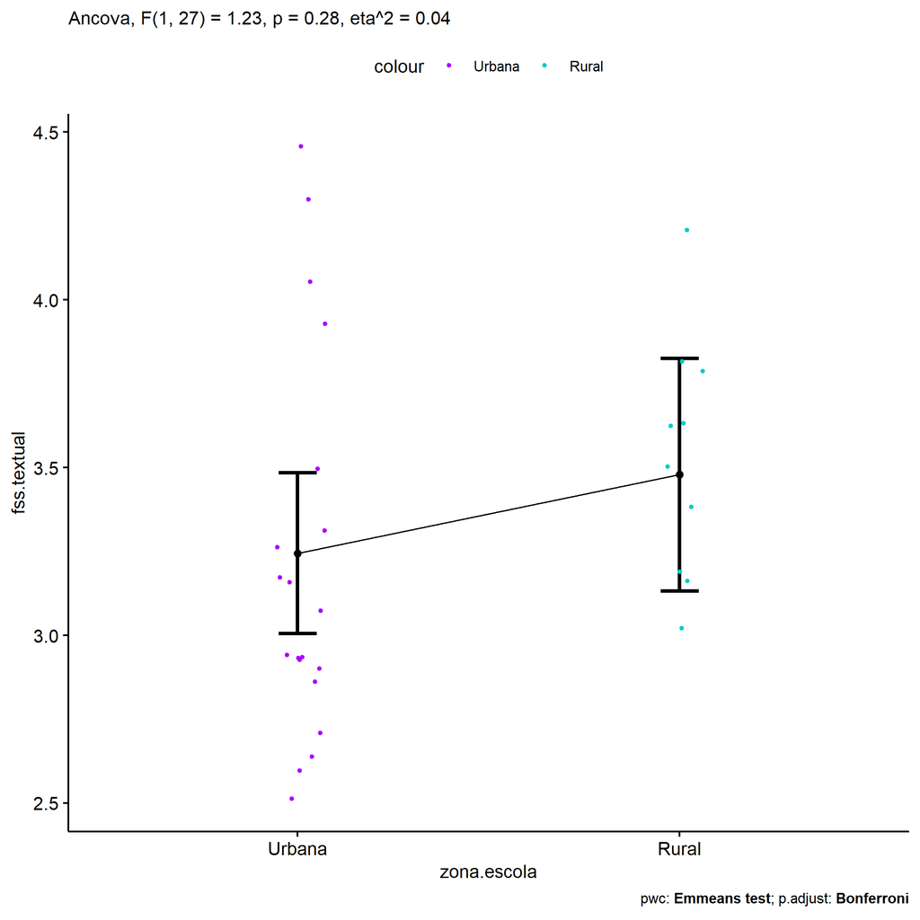

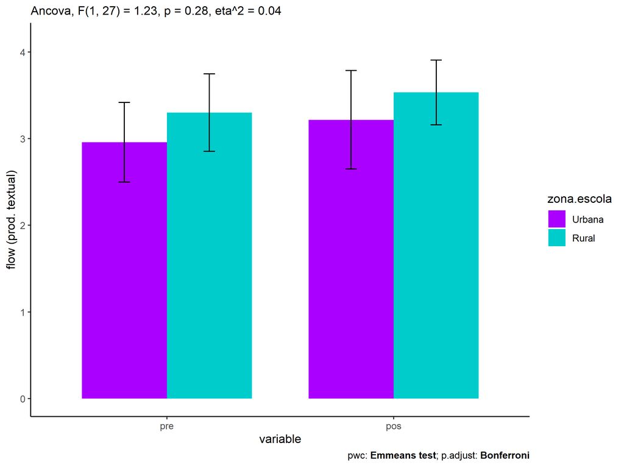

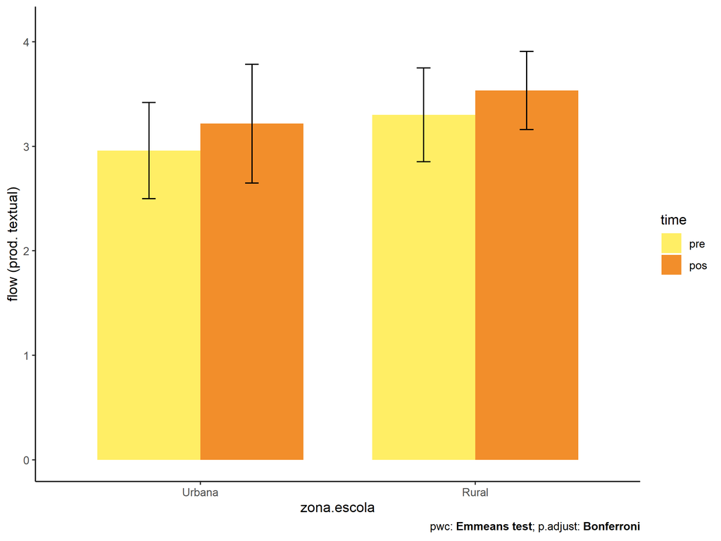

## Pairwise comparisons for two factors

### factores: **grupo:genero**

| var | grupo | genero | n | M (pre) | SE (pre) | M (unadj) | SE (unadj) | M (adj) | SE (adj) |
| --- | --- | --- | --- | --- | --- | --- | --- | --- | --- |
| fss.textual | Controle | F | 6 | 2.963 | 0.121 | 3.426 | 0.221 | 3.448 | 0.209 |
| fss.textual | Controle | M | 8 | 2.981 | 0.186 | 3.085 | 0.196 | 3.105 | 0.181 |
| fss.textual | stari+WG | M | 12 | 3.278 | 0.129 | 3.454 | 0.125 | 3.430 | 0.150 |

|  | .y. | grupo | genero | group1 | group2 | estimate | conf.low | conf.high | se | statistic | p | p.adj | p.adj.signif |
| --- | --- | --- | --- | --- | --- | --- | --- | --- | --- | --- | --- | --- | --- |
| 2 | fss.textual |  | M | Controle | stari+WG | -0.325 | -0.823 | 0.173 | 0.240 | -1.354 | 0.190 | 0.190 | ns |
| 4 | dfs.textual |  | M | Controle | stari+WG | -0.297 | -0.719 | 0.125 | 0.204 | -1.457 | 0.159 | 0.159 | ns |
| 5 | fss.textual | Controle |  | F | M | 0.343 | -0.220 | 0.907 | 0.272 | 1.263 | 0.220 | 0.220 | ns |
| 7 | dfs.textual | Controle |  | F | M | -0.018 | -0.517 | 0.481 | 0.241 | -0.074 | 0.941 | 0.941 | ns |

| .y. | grupo | genero | group1 | group2 | estimate | conf.low | conf.high | se | statistic | p | p.adj | p.adj.signif |
| --- | --- | --- | --- | --- | --- | --- | --- | --- | --- | --- | --- | --- |
| flow.textual | Controle | F | pre | pos | -0.463 | -1.012 | 0.086 | 0.273 | -1.698 | 0.096 | 0.096 | ns |
| flow.textual | Controle | M | pre | pos | -0.104 | -0.579 | 0.371 | 0.236 | -0.441 | 0.661 | 0.661 | ns |
| flow.textual | stari+WG | M | pre | pos | -0.176 | -0.564 | 0.212 | 0.193 | -0.912 | 0.366 | 0.366 | ns |

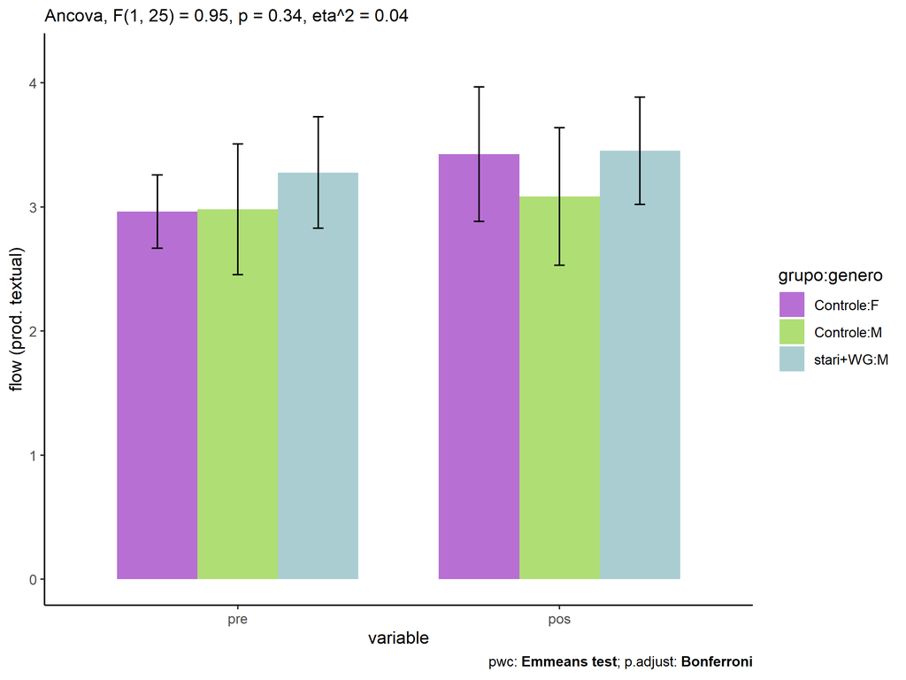

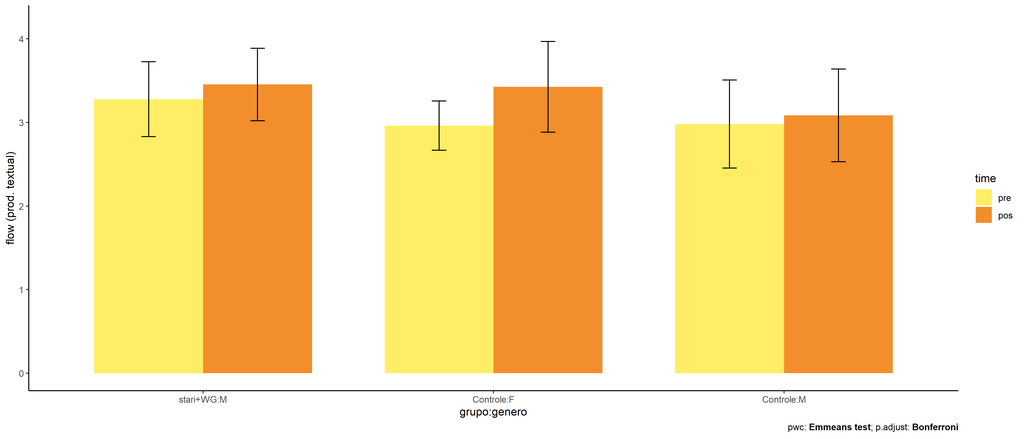

### factores: **grupo:idade**

### factores: **grupo:zona.participante**

| var | grupo | zona.participante | n | M (pre) | SE (pre) | M (unadj) | SE (unadj) | M (adj) | SE (adj) |
| --- | --- | --- | --- | --- | --- | --- | --- | --- | --- |
| fss.textual | Controle | Urbana | 9 | 3.049 | 0.158 | 3.273 | 0.206 | 3.298 | 0.203 |
| fss.textual | stari+WG | Rural | 5 | 3.152 | 0.237 | 3.444 | 0.217 | 3.452 | 0.267 |
| fss.textual | stari+WG | Urbana | 6 | 3.463 | 0.198 | 3.463 | 0.244 | 3.420 | 0.255 |

|  | .y. | grupo | zona.participante | group1 | group2 | estimate | conf.low | conf.high | se | statistic | p | p.adj | p.adj.signif |
| --- | --- | --- | --- | --- | --- | --- | --- | --- | --- | --- | --- | --- | --- |
| 1 | fss.textual |  | Urbana | Controle | stari+WG | -0.122 | -0.836 | 0.592 | 0.337 | -0.361 | 0.723 | 0.723 | ns |
| 3 | dfs.textual |  | Urbana | Controle | stari+WG | -0.414 | -0.960 | 0.133 | 0.259 | -1.598 | 0.128 | 0.128 | ns |
| 6 | fss.textual | stari+WG |  | Urbana | Rural | -0.033 | -0.822 | 0.756 | 0.372 | -0.088 | 0.931 | 0.931 | ns |
| 8 | dfs.textual | stari+WG |  | Urbana | Rural | 0.311 | -0.317 | 0.938 | 0.297 | 1.044 | 0.311 | 0.311 | ns |

| .y. | grupo | zona.participante | group1 | group2 | estimate | conf.low | conf.high | se | statistic | p | p.adj | p.adj.signif |
| --- | --- | --- | --- | --- | --- | --- | --- | --- | --- | --- | --- | --- |
| flow.textual | Controle | Urbana | pre | pos | -0.224 | -0.740 | 0.293 | 0.254 | -0.880 | 0.385 | 0.385 | ns |
| flow.textual | stari+WG | Urbana | pre | pos | 0.000 | -0.633 | 0.633 | 0.311 | 0.000 | 1.000 | 1.000 | ns |
| flow.textual | stari+WG | Rural | pre | pos | -0.292 | -0.985 | 0.401 | 0.341 | -0.856 | 0.398 | 0.398 | ns |

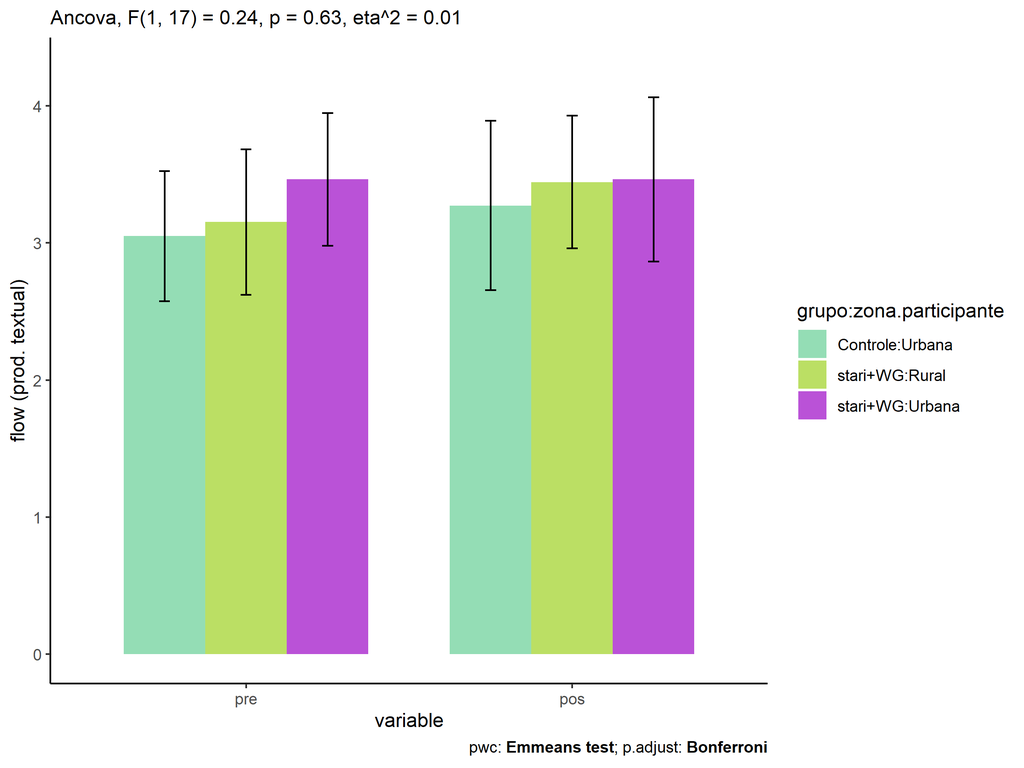

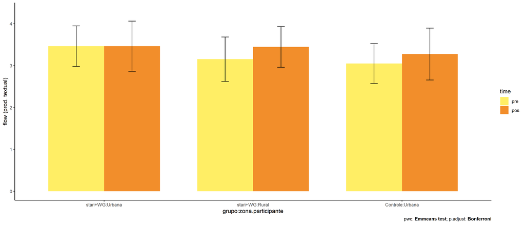

### factores: **grupo:escola**

| var | grupo | escola | n | M (pre) | SE (pre) | M (unadj) | SE (unadj) | M (adj) | SE (adj) |
| --- | --- | --- | --- | --- | --- | --- | --- | --- | --- |
| fss.textual | Controle | E1 | 5 | 2.911 | 0.257 | 3.267 | 0.301 | 3.314 | 0.271 |
| fss.textual | Controle | E5 | 5 | 2.992 | 0.199 | 3.158 | 0.278 | 3.181 | 0.268 |
| fss.textual | stari+WG | E4 | 5 | 3.511 | 0.250 | 3.444 | 0.214 | 3.311 | 0.293 |
| fss.textual | stari+WG | E5 | 7 | 2.918 | 0.185 | 3.333 | 0.230 | 3.378 | 0.229 |

|  | .y. | grupo | escola | group1 | group2 | estimate | conf.low | conf.high | se | statistic | p | p.adj | p.adj.signif |
| --- | --- | --- | --- | --- | --- | --- | --- | --- | --- | --- | --- | --- | --- |
| 3 | fss.textual |  | E5 | Controle | stari+WG | -0.197 | -0.936 | 0.542 | 0.350 | -0.562 | 0.581 | 0.581 | ns |
| 6 | dfs.textual |  | E5 | Controle | stari+WG | 0.073 | -0.562 | 0.709 | 0.302 | 0.242 | 0.811 | 0.811 | ns |
| 8 | fss.textual | Controle |  | E1 | E5 | 0.133 | -0.666 | 0.931 | 0.378 | 0.350 | 0.731 | 0.731 | ns |
| 12 | fss.textual | stari+WG |  | E4 | E5 | -0.067 | -0.880 | 0.746 | 0.385 | -0.174 | 0.864 | 0.864 | ns |
| 14 | dfs.textual | Controle |  | E1 | E5 | -0.081 | -0.767 | 0.606 | 0.327 | -0.247 | 0.808 | 0.808 | ns |
| 18 | dfs.textual | stari+WG |  | E4 | E5 | 0.593 | -0.043 | 1.228 | 0.302 | 1.960 | 0.066 | 0.066 | ns |

| .y. | grupo | escola | group1 | group2 | estimate | conf.low | conf.high | se | statistic | p | p.adj | p.adj.signif |
| --- | --- | --- | --- | --- | --- | --- | --- | --- | --- | --- | --- | --- |
| flow.textual | Controle | E1 | pre | pos | -0.356 | -1.074 | 0.363 | 0.354 | -1.003 | 0.322 | 0.322 | ns |
| flow.textual | Controle | E5 | pre | pos | -0.167 | -0.885 | 0.552 | 0.354 | -0.470 | 0.641 | 0.641 | ns |
| flow.textual | stari+WG | E4 | pre | pos | 0.067 | -0.652 | 0.785 | 0.354 | 0.188 | 0.852 | 0.852 | ns |
| flow.textual | stari+WG | E5 | pre | pos | -0.415 | -1.022 | 0.192 | 0.300 | -1.385 | 0.174 | 0.174 | ns |

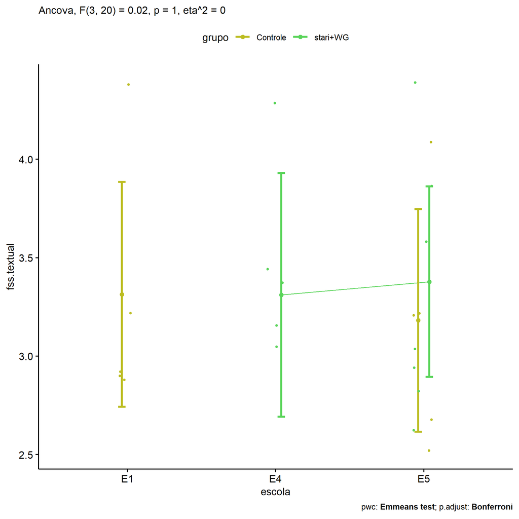

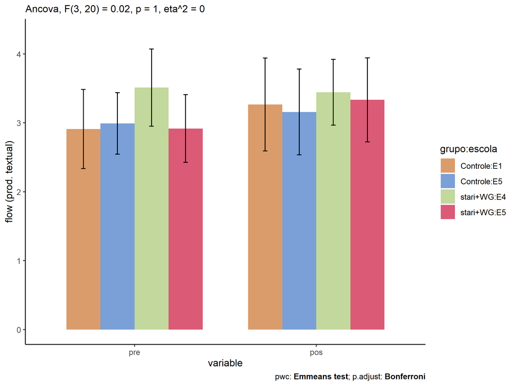

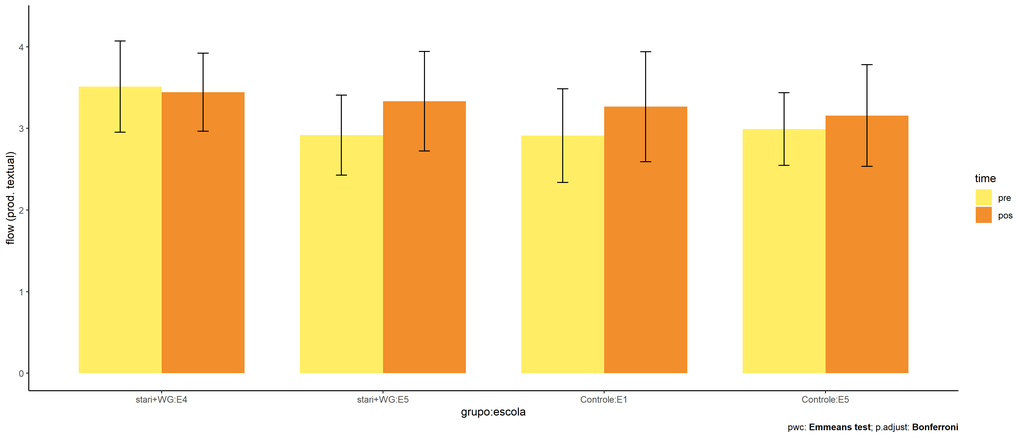

### factores: **grupo:zona.escola**

| var | grupo | zona.escola | n | M (pre) | SE (pre) | M (unadj) | SE (unadj) | M (adj) | SE (adj) |
| --- | --- | --- | --- | --- | --- | --- | --- | --- | --- |
| fss.textual | Controle | Urbana | 11 | 2.926 | 0.142 | 3.163 | 0.183 | 3.194 | 0.168 |
| fss.textual | stari+WG | Rural | 7 | 3.365 | 0.198 | 3.556 | 0.164 | 3.487 | 0.218 |
| fss.textual | stari+WG | Urbana | 9 | 2.998 | 0.158 | 3.284 | 0.182 | 3.299 | 0.183 |

|  | .y. | grupo | zona.escola | group1 | group2 | estimate | conf.low | conf.high | se | statistic | p | p.adj | p.adj.signif |
| --- | --- | --- | --- | --- | --- | --- | --- | --- | --- | --- | --- | --- | --- |
| 1 | fss.textual |  | Urbana | Controle | stari+WG | -0.104 | -0.615 | 0.406 | 0.247 | -0.423 | 0.676 | 0.676 | ns |
| 3 | dfs.textual |  | Urbana | Controle | stari+WG | -0.073 | -0.523 | 0.377 | 0.218 | -0.334 | 0.742 | 0.742 | ns |
| 6 | fss.textual | stari+WG |  | Urbana | Rural | -0.188 | -0.785 | 0.410 | 0.289 | -0.650 | 0.522 | 0.522 | ns |
| 8 | dfs.textual | stari+WG |  | Urbana | Rural | -0.367 | -0.871 | 0.138 | 0.244 | -1.501 | 0.146 | 0.146 | ns |

| .y. | grupo | zona.escola | group1 | group2 | estimate | conf.low | conf.high | se | statistic | p | p.adj | p.adj.signif |
| --- | --- | --- | --- | --- | --- | --- | --- | --- | --- | --- | --- | --- |
| flow.textual | Controle | Urbana | pre | pos | -0.237 | -0.681 | 0.206 | 0.221 | -1.076 | 0.287 | 0.287 | ns |
| flow.textual | stari+WG | Urbana | pre | pos | -0.286 | -0.776 | 0.205 | 0.244 | -1.172 | 0.247 | 0.247 | ns |
| flow.textual | stari+WG | Rural | pre | pos | -0.190 | -0.746 | 0.365 | 0.277 | -0.689 | 0.494 | 0.494 | ns |

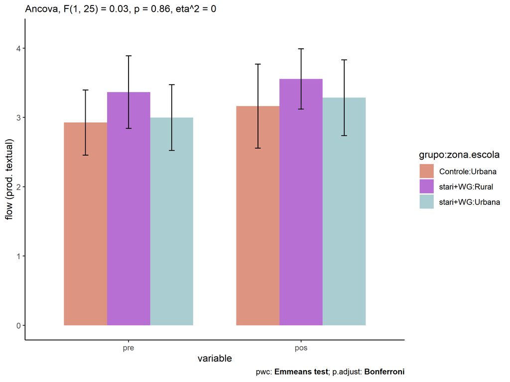

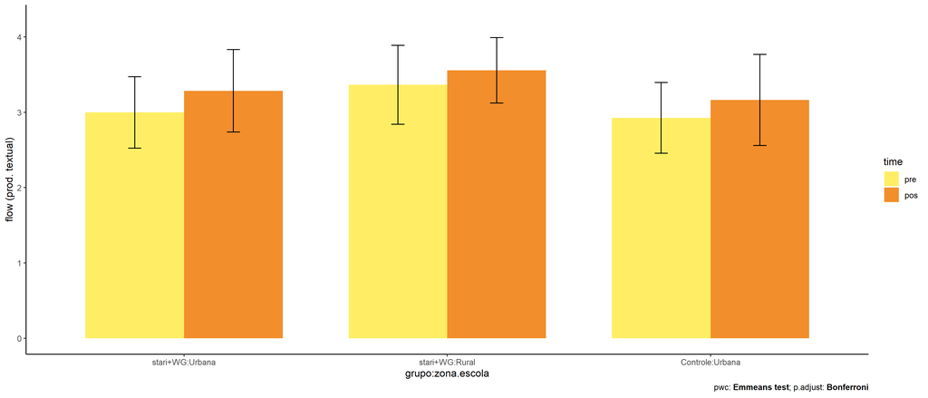

## Pairwise comparisons for grupo=“Experimental”

### factores: **grupo=“Experimental”:monitor**

### factores: **grupo=“Experimental”:monitor.genero**

### factores: **grupo=“Experimental”:monitor.area**

### factores: **grupo=“Experimental”:monitor.formacao**

| var | monitor.formacao | n | M (pre) | SE (pre) | M (unadj) | SE (unadj) | M (adj) | SE (adj) |
| --- | --- | --- | --- | --- | --- | --- | --- | --- |
| fss.textual | ensino medio | 5 | 2.956 | 0.215 | 3.333 | 0.230 | 3.297 | 0.255 |
| fss.textual | especializacao | 5 | 3.511 | 0.250 | 3.444 | 0.214 | 3.481 | 0.255 |

| .y. | group1 | group2 | estimate | conf.low | conf.high | se | statistic | p | p.adj | p.adj.signif |
| --- | --- | --- | --- | --- | --- | --- | --- | --- | --- | --- |
| fss.textual | ensino medio | especializacao | -0.184 | -1.099 | 0.732 | 0.387 | -0.474 | 0.650 | 0.650 | ns |
| dfs.textual | ensino medio | especializacao | -0.556 | -1.316 | 0.205 | 0.330 | -1.684 | 0.131 | 0.131 | ns |

| .y. | monitor.formacao | group1 | group2 | estimate | conf.low | conf.high | se | statistic | p | p.adj | p.adj.signif |
| --- | --- | --- | --- | --- | --- | --- | --- | --- | --- | --- | --- |
| flow.textual | ensino medio | pre | pos | -0.378 | -1.061 | 0.305 | 0.322 | -1.172 | 0.258 | 0.258 | ns |
| flow.textual | especializacao | pre | pos | 0.067 | -0.616 | 0.750 | 0.322 | 0.207 | 0.839 | 0.839 | ns |

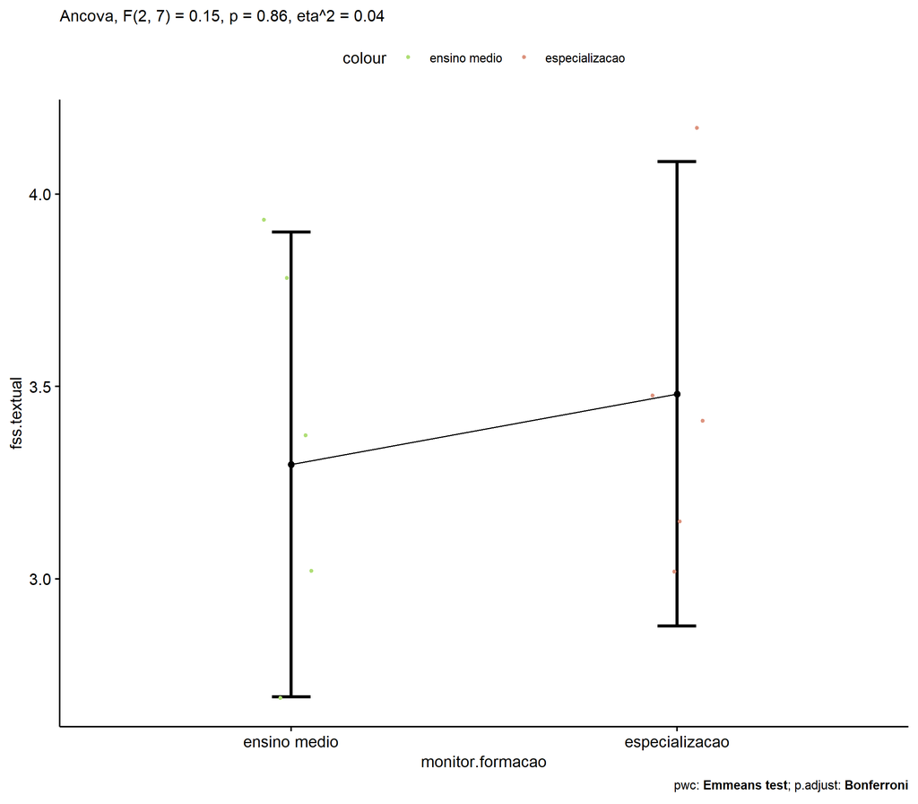

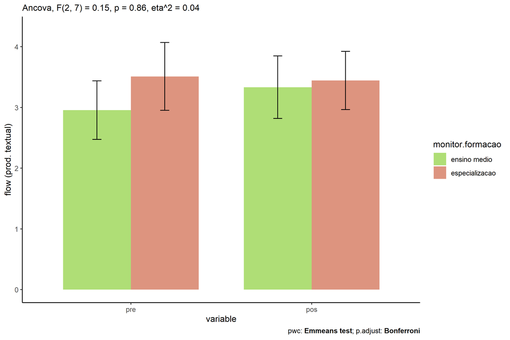

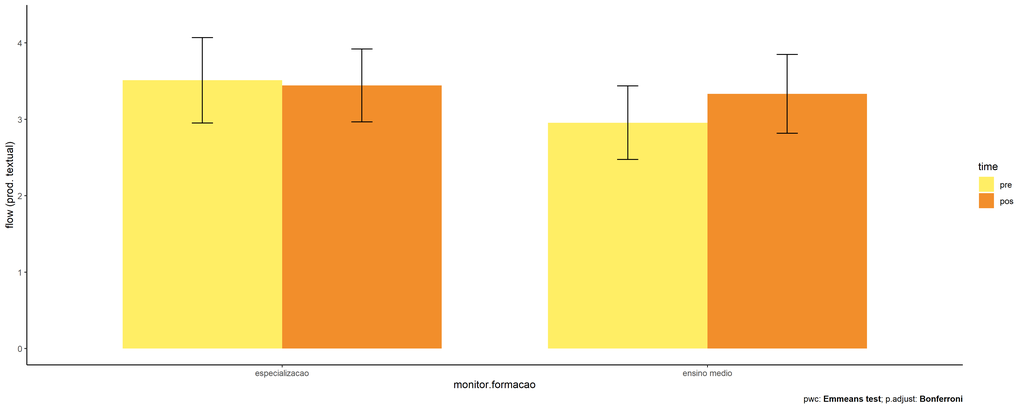

### factores: **grupo=“Experimental”:monitor.experiencia**